# R Notebook

## Front Matter

```r
# clean up workspace environment
rm(list = ls())
# all packages used for the assignment
library(DataComputing)
library(tidyr)
library(ggplot2)
library(dplyr)
```

```r
NMC_5.0 <-
read.csv(file.choose())
```

```r
NMC_5.0
```

[output not shown]

## Guiding Question

How have economic, military, and population changes across the globe and across many years transformed the United States into the “global hegemon,” and is this “hegemony” secure?

## Data Sources

### National Material Capabilites v5.0

I discovered the National Material Capabilities data-set during one of my previous political science courses. I was a student in Dr. Robert Packer’s PLSC 438, National Security Politics course. As Dr. Packer was one of the coders who helped in the creation of this study, he discussed it and the data within at several points during the semester. This data was initially collected by a group of researchers in the 1960’s to better understand how the major global powers had become just that, global powers. The Data set has also been updated over the years, with the version 3.0 update having been conducted by our own university, Penn State in 2005, and the most recent update having been conducted in 2017. The data-set is hosted by J Michael Greig and Andrew Enterline from the University of North Texas, and the Correlates of War Data Set Hosting Program.

In the data-set, each case represents one country and its 10 attributes for a given year. These attributes include military expenditure, number of active servicemen in the millions, a state abbreviation, the version of study in which the data was generated, the year, the iron and steel production of the country, the primary energy expenditure of the country, the total and urban populations of the country, and the COmposite Index of National Capabilities Score for each country. This final variable is computed based on the six population, energy, military, and production variables, and it used to describe the “power” each country holds.

```r
NMC_5.0 %>% summarise(n())
```

| n() |
| --- |
| 15171 |

This data-set consists of 15,171 cases. This is primarily due to the fact that this data-set covers several countries from 1816 to 2012.

Some of the variables I will work directly with will include the CINC score, the year, and the six population, energy, military, and production variables (irst, pec, milex, milper, tpop, upop).

### Plots

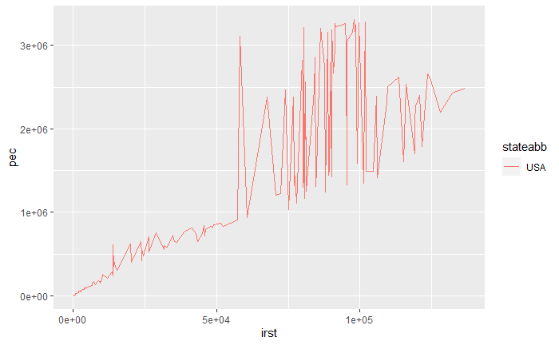

```r
NMC_5.0 %>% filter(stateabb == "USA") %>% ggplot(aes(x = irst, y = pec)) + geom_line() + aes(color = stateabb)
```

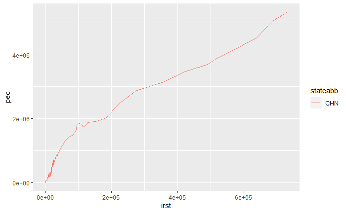

```r
NMC_5.0 %>% filter(stateabb == "CHN") %>% ggplot(aes(x = irst, y = pec)) + geom_line() + aes(color = stateabb)
```

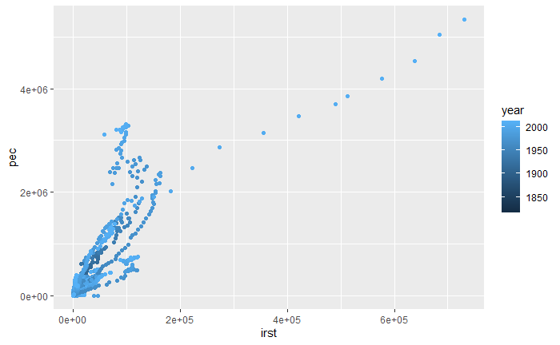

```r
NMC_5.0 %>% ggplot(aes(x = irst, y = pec)) + geom_point() + aes(color = year)
```

## World Cities

My second data set will be the World Cities data-set from the DataComputing package. As my research question also relates to population, understanding which countries have the most populous cities.I found this data-set through our work with it during the DC exercises assignments. Although we never directly utilized it, it is similar in structure to that of the ZipGeography data-set with the exception that it focuses on cities in countries other than the United States. As my research project has an international focus, it was important to utilize a data-set that reflected that focus.This data-set was collected over the course of several years during the first two decades of the 21st century. The data was also collected by researchers who used census data, and other population studies to create this data-set.

```r
data("WorldCities")
```

```r
WorldCities
```

| code | name | latitude | longitude | country | countryRegion | population | regionCode | region | date |
| --- | --- | --- | --- | --- | --- | --- | --- | --- | --- |
| 3040051 | les Escaldes | 42.50729 | 1.53414 | AD | 8 | 15853 | 1033 | Europe/Andorra | 10/15/08 |
| 3041563 | Andorra la Vella | 42.50779 | 1.52109 | AD | 7 | 20430 | 1037 | Europe/Andorra | 5/30/10 |
| 290594 | Umm al Qaywayn | 25.56473 | 55.55517 | AE | 7 | 44411 | 2 | Asia/Dubai | 11/3/12 |
| 291074 | Ra's al Khaymah | 25.78953 | 55.94320 | AE | 5 | 115949 | 2 | Asia/Dubai | 11/30/12 |
| 291696 | Khawr Fakkan | 25.33132 | 56.34199 | AE | 6 | 33575 | 20 | Asia/Dubai | 11/3/12 |
| 292223 | Dubai | 25.25817 | 55.30472 | AE | 3 | 1137347 | 11 | Asia/Dubai | 8/19/12 |
| 292239 | Diba | 25.61955 | 56.27291 | AE | 4 | 26395 | 4 | Asia/Dubai | 7/6/13 |
| 292672 | Sharjah | 25.33737 | 55.41206 | AE | 6 | 543733 | 6 | Asia/Dubai | 3/5/13 |
| 292688 | Ar Ruways | 24.11028 | 52.73056 | AE | 1 | 16000 | 16 | Asia/Dubai | 11/3/12 |
| 292878 | Al Fujayrah | 25.11641 | 56.34141 | AE | 4 | 62415 | 15 | Asia/Dubai | 1/18/12 |

[output cut: 990 more lines]

In the data-set, each case represents on city in a country for a certain date. Some of the variables I intend to use are the country abbreviation, the population, and “countryRegion” in order to create a chloropleth map of the data-set. I plan to use this resulting map to better understand the number of major trade locations in each country, and to determine if the number of cities correlates to the economic power of country.

```r
WorldCities %>% summarise(n())
```

| n() |
| --- |
| 23018 |

In the data-set, there are 23,018 cases, so there is plenty of data for my project and it also includes data for several of the countries I will be looking at intensely; China, the US, and Russia.

### Plots

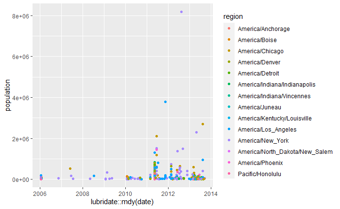

```r
WorldCities %>% filter(country == "US") %>% ggplot(aes(y = population, x = lubridate::mdy(date))) + geom_point() + aes(color = region)
```

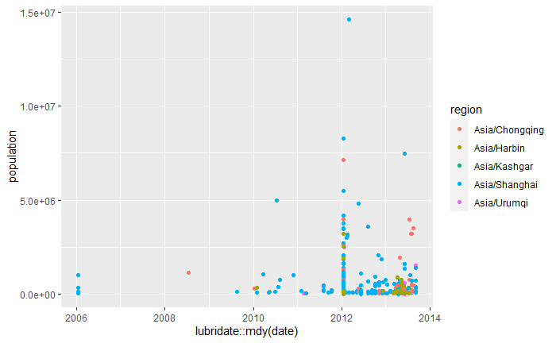

```r
WorldCities %>% filter(country == "CN") %>% ggplot(aes(y = population, x = lubridate::mdy(date))) + geom_point() + aes(color = region)
```

In comparison to the US, a large number of cities in China are more heavily concentrated near the Pacific Ocean. This would suggest that while China has several major trade hubs, the distribution of economic success in the country is not as even. However, there appears to be more of these trade-hubs in china than in the US. Details like this will also allow me to better understand where the economic power of the US’ “challengers” comes from, adn will provide more insight into the accuracy of the CINC scores in the NMC v5.0 dataset.

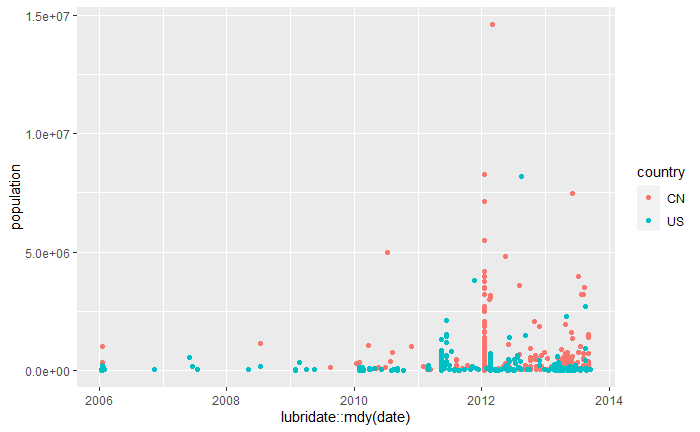

```r
pair <- c("CN", "US")
WorldCities %>% filter(country %in% pair) %>% ggplot(aes(y = population, x = lubridate::mdy(date))) + geom_point() + aes(color = country)
```